# Question

Se midieron las estaturas (en cm) de un grupo de estudiantes. Los datos obtenidos son:

| Estudiante | Estatura..cm. |
| --- | --- |
| 1 | 181 |
| 2 | 185 |
| 3 | 177 |
| 4 | 178 |
| 5 | 182 |
| 6 | 178 |
| 7 | 178 |
| 8 | 162 |
| 9 | 179 |
| 10 | 164 |
| 11 | 174 |
| 12 | 163 |
| 13 | 179 |
| 14 | 178 |
| 15 | 175 |
| 16 | 186 |
| 17 | 180 |
| 18 | 185 |
| 19 | 169 |
| 20 | 176 |

Responda las siguientes preguntas basándose en los datos proporcionados:

1. **(schoice)** ¿Cuál es el valor del primer cuartil (Q1)? Answerlist ———-
- 170.5
- 176.5
- 174
- 174.5
2. **(mchoice)** Seleccione los valores que corresponden a cuartiles de los datos. Answerlist ———-
- 162
- 174.5
- 178
- 180.5
- 186
3. **(verdadero/falso)** La mediana de los datos es igual al valor de Q2 calculado con el método tradicional.  
   Answerlist ———-
- Verdadero
- Falso
4. **(num)** ¿Cuál es el valor del tercer cuartil (Q3)? Escriba su respuesta con un decimal si es necesario.
5. **(string)** ¿Cuál es el valor de la mediana de los datos? Escriba el número como texto.

# Solution

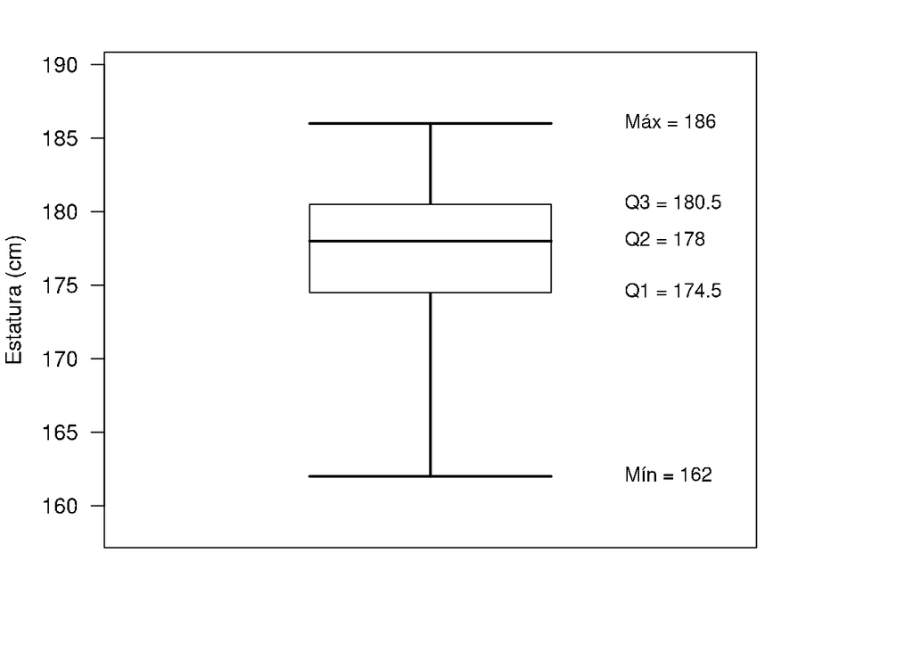

# Meta-information